# Age Specific Mortality Rate Trends

# Intro

This doc will describe some of the average trends at specific ages from 21 high income countries.

It is inspired by Christensen 2010, which showed

- Probability of dying in next 12 months
- At age 80 and age 90
- Males and females
- Selected countries
  - England & Wales
  - France
  - East Germany
  - West Germany
  - Japan
  - Sweden
  - USA

The aim will be to determine how strongly the (log of these) trends are correlated.

# Pre reqs

```r
pacman::p_load(
  tidyverse, HMDHFDplus,
  ggrepel
)
dta_Mx <- read_rds("tidy_data/Mx_data.rds")
```

Define countries

```r
source("scripts/country_definitions.R")
```

# Replication of Fig 2 of Christenson et al 2010

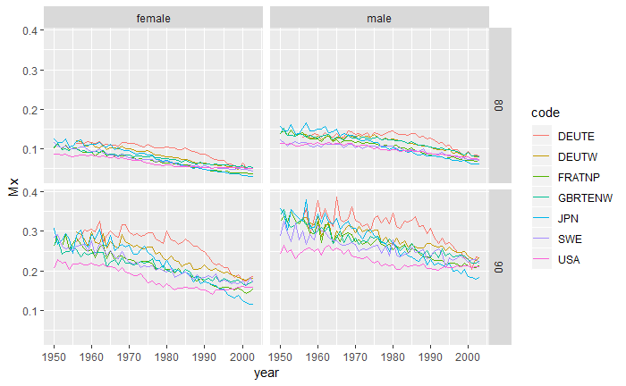

```r
dta_Mx %>%
  filter(sex != "total") %>%
  filter(age %in% c(80, 90)) %>%
  filter(
    code %in% c("GBRTENW", "FRATNP", "DEUTE", "DEUTW", "JPN", "SWE", "USA")
  ) %>%
  filter(between(year, 1950, 2003)) %>%
  ggplot(
    aes(x = year, y = Mx, colour = code, group = code)
  ) +
  geom_line() +
  facet_grid(age ~ sex)
```

And how has this developed since?

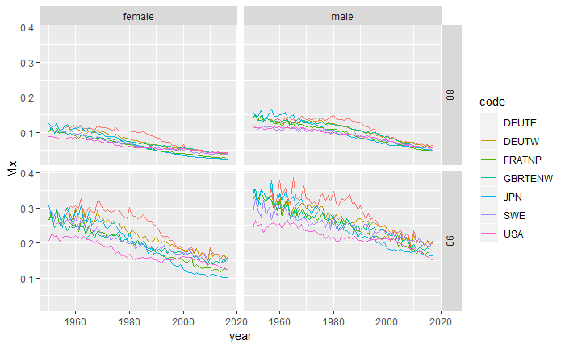

```r
dta_Mx %>%
  filter(sex != "total") %>%
  filter(age %in% c(80, 90)) %>%
  filter(
    code %in% c("GBRTENW", "FRATNP", "DEUTE", "DEUTW", "JPN", "SWE", "USA")
  ) %>%
  filter(between(year, 1950, 2017)) %>%
  ggplot(
    aes(x = year, y = Mx, colour = code, group = code)
  ) +
  geom_line() +
  facet_grid(age ~ sex)
```

It’s interesting that life expectancies have at age 80 have converged, for males especially. And that they’ve levelled off in Japan over the 2000s, while continued to improve in the USA.

Let’s look at this for the average of the 21 countries

Now let’s do this for the average of the 21 high income countries

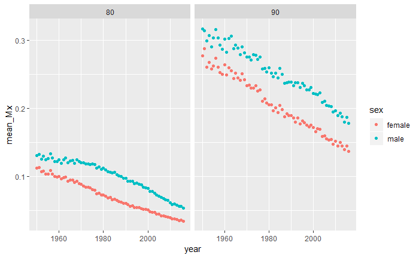

```r
dta_Mx %>%
  filter(sex != "total") %>%
  filter(age %in% c(80, 90)) %>%
  filter(code %in% high_income_countries) %>%
  filter(between(year, 1950, 2016)) %>%
  group_by(year, age, sex) %>%
  summarise(mean_Mx = mean(Mx, na.rm = T)) %>%
  ungroup() %>%
  ggplot(aes(x = year, y = mean_Mx, colour = sex)) +
  facet_wrap(~age) +
  geom_point()
```

Let’s now use log rather than linear

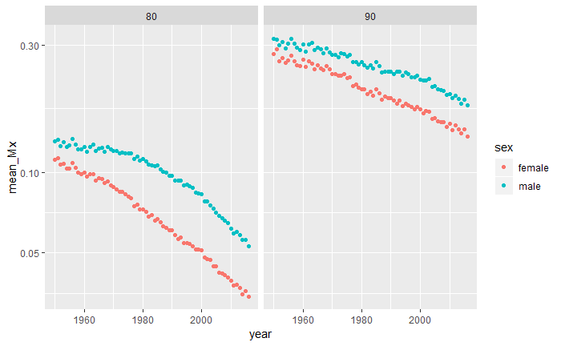

```r
dta_Mx %>%
  filter(sex != "total") %>%
  filter(age %in% c(80, 90)) %>%
  filter(code %in% high_income_countries) %>%
  filter(between(year, 1950, 2016)) %>%
  group_by(year, age, sex) %>%
  summarise(mean_Mx = mean(Mx, na.rm = T)) %>%
  ungroup() %>%
  ggplot(aes(x = year, y = mean_Mx, colour = sex)) +
  facet_wrap(~age) +
  geom_point() +
  scale_y_log10()
```

So, the trends on % reductions have been more continuous for age 90 than age 80, and more continuous for females than males.

Let’s now do this for a couple of additional age groups

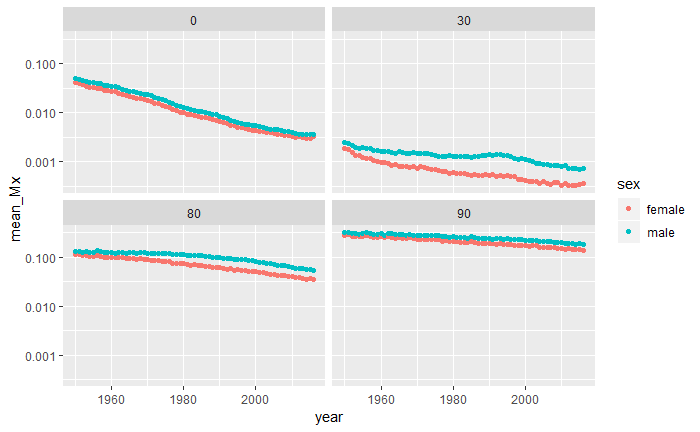

```r
dta_Mx %>%
  filter(sex != "total") %>%
  filter(age %in% c(0, 30, 80, 90)) %>%
  filter(code %in% high_income_countries) %>%
  filter(between(year, 1950, 2016)) %>%
  group_by(year, age, sex) %>%
  summarise(mean_Mx = mean(Mx, na.rm = T)) %>%
  ungroup() %>%
  ggplot(aes(x = year, y = mean_Mx, colour = sex)) +
  facet_wrap(~age) +
  geom_point() +
  scale_y_log10()
```

Now let’s estimate the correlation between these trends

```r
dta_trnd <- dta_Mx %>%
  filter(sex == "total") %>%
  filter(between(year, 1955, 2016))  %>%
  filter(age %in% c(0, 30, 80, 90)) %>%
  group_by(year, age) %>%
  summarise(mean_Mx = mean(Mx, na.rm = T)) %>%
  ungroup() %>%
  mutate(log_mean_Mx = log(mean_Mx, 10))
dta_trnd %>%
  select(-mean_Mx) %>%
  mutate(age = paste0("age_", age)) %>%
  spread(age, log_mean_Mx) %>%
  select(-year) %>%
  cor()
```

```
           age_0    age_30    age_80    age_90
age_0  1.0000000 0.9201582 0.9765313 0.9827364
age_30 0.9201582 1.0000000 0.9502384 0.9410485
age_80 0.9765313 0.9502384 1.0000000 0.9855633
age_90 0.9827364 0.9410485 0.9855633 1.0000000
```

Let’s do this as a heatmap for all ages

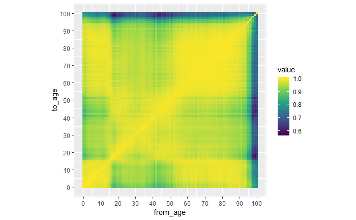

```r
dta_trnd <- dta_Mx %>%
  filter(sex == "total") %>%
  filter(between(year, 1955, 2016))  %>%
  filter(age <= 109) %>%
  group_by(year, age) %>%
  summarise(mean_Mx = mean(Mx, na.rm = T)) %>%
  ungroup() %>%
  mutate(log_mean_Mx = log(mean_Mx, 10))
tmp <- dta_trnd %>%
  select(-mean_Mx) %>%
  spread(age, log_mean_Mx) %>%
  select(-year) %>%
  cor()
cor_df <- tmp %>%
  as_tibble() %>%
  mutate(from_age = rownames(tmp)) %>%
  gather(key="to_age", value = "value", -from_age) %>%
  mutate(from_age = as.numeric(from_age), to_age = as.numeric(to_age))
cor_df %>%
  filter(from_age <= 100, to_age <= 100) %>%
  ggplot(aes(x = from_age, y = to_age, fill = value)) +
  geom_tile() +
  scale_fill_viridis_c() +
  scale_x_continuous(breaks = seq(0, 100, by = 10)) +
  scale_y_continuous(breaks = seq(0, 100, by = 10)) +
  coord_equal()
```

Definitely a ‘wow’ figure!

Interesting that the trends that apply at older ages don’t apply at the oldest ages (from around age 96 onwards)

Let’s see how different it looks by gender.

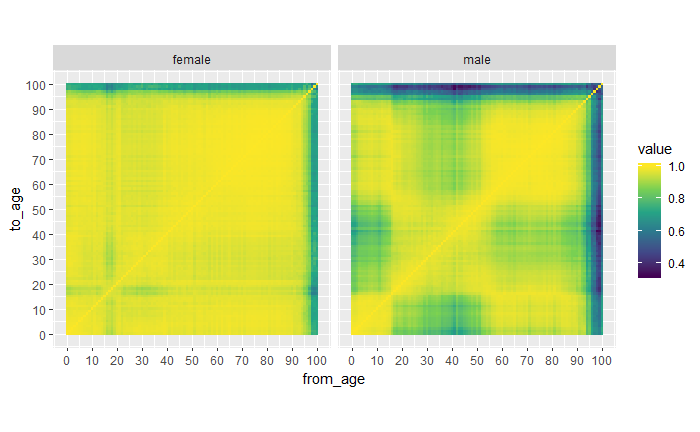

```r
dta_trnd <- dta_Mx %>%
  filter(sex != "total") %>%
  filter(between(year, 1955, 2016))  %>%
  filter(age <= 109) %>%
  group_by(sex, year, age) %>%
  summarise(mean_Mx = mean(Mx, na.rm = T)) %>%
  ungroup() %>%
  mutate(log_mean_Mx = log(mean_Mx, 10)) %>%
  group_by(sex) %>%
  nest()
cors_df <- dta_trnd %>%
  mutate(cors = map(
    data,
    function(X) {
      X %>%
        select(-mean_Mx) %>%
        spread(age, log_mean_Mx) %>%
        select(-year) %>%
        cor()
      }
    )
  ) %>%
  mutate(cor_df = map(
    cors,
    function(X){
      X %>%
        as_tibble() %>%
        mutate(from_age = rownames(X)) %>%
        gather(key = "to_age", value = "value", -from_age) %>%
        mutate(from_age = as.numeric(from_age), to_age = as.numeric(to_age))
      }
    )
  ) %>%
  select(sex, cor_df) %>%
  unnest()
cors_df %>%
  filter(from_age <= 100, to_age <= 100) %>%
  ggplot(aes(x = from_age, y = to_age, fill = value)) +
  geom_tile() +
  scale_fill_viridis_c() +
  scale_x_continuous(breaks = seq(0, 100, by = 10)) +
  scale_y_continuous(breaks = seq(0, 100, by = 10)) +
  coord_equal() +
  facet_wrap(~sex)
```

Again, beautiful, staggering, and awesome. This is like seeing the genome of population health improvement being mapped. The gender differences in the differences in correlation are very apparent.

Let’s extend this to a few few select countries:

- France
- Sweden?
- UK
- USA
- Spain (Identified as most compatible with Lee-Carter modelling approach)
- Japan

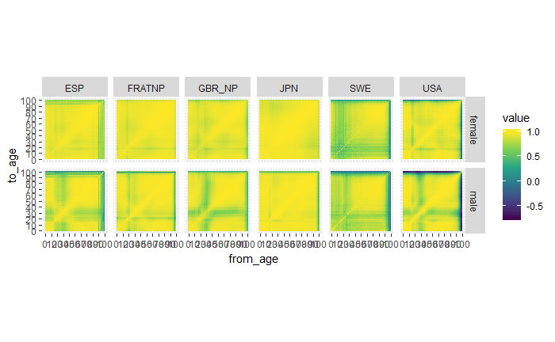

```r
dta_trnd <- dta_Mx %>%
  filter(sex != "total") %>%
  filter(code %in% c("FRATNP", "SWE", "GBR_NP", "USA", "ESP", "JPN")) %>%
  filter(between(year, 1955, 2016))  %>%
  filter(age <= 109) %>%
  group_by(code, sex, year, age) %>%
  summarise(mean_Mx = mean(Mx, na.rm = T)) %>%
  ungroup() %>%
  mutate(log_mean_Mx = log(mean_Mx + 0.00001, 10)) %>% # Correction for Sweden
  group_by(sex, code) %>%
  nest()
cors_df <- dta_trnd %>%
  mutate(cors = map(
    data,
    function(X) {
      X %>%
        select(-mean_Mx) %>%
        spread(age, log_mean_Mx) %>%
        select(-year) %>%
        cor()
      }
    )
  ) %>%
  mutate(cor_df = map(
    cors,
    function(X){
      X %>%
        as_tibble() %>%
        mutate(from_age = rownames(X)) %>%
        gather(key = "to_age", value = "value", -from_age) %>%
        mutate(from_age = as.numeric(from_age), to_age = as.numeric(to_age))
      }
    )
  ) %>%
  select(sex, code, cor_df) %>%
  unnest()
cors_df %>%
  filter(from_age <= 100, to_age <= 100) %>%
  ggplot(aes(x = from_age, y = to_age, fill = value)) +
  geom_tile() +
  scale_fill_viridis_c() +
  scale_x_continuous(breaks = seq(0, 100, by = 10)) +
  scale_y_continuous(breaks = seq(0, 100, by = 10)) +
  coord_equal() +
  facet_grid(sex ~ code)
```

Let’s do this just for the UK nations

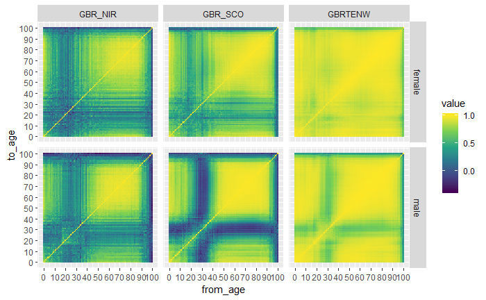

```r
dta_trnd <- dta_Mx %>%
  filter(sex != "total") %>%
  filter(code %in% c("GBRTENW", "GBR_SCO", "GBR_NIR")) %>%
  filter(between(year, 1955, 2016))  %>%
  filter(age <= 109) %>%
  group_by(code, sex, year, age) %>%
  summarise(mean_Mx = mean(Mx, na.rm = T)) %>%
  ungroup() %>%
  mutate(log_mean_Mx = log(mean_Mx + 0.00001, 10)) %>% # Correction for Sweden
  group_by(sex, code) %>%
  nest()
cors_df <- dta_trnd %>%
  mutate(cors = map(
    data,
    function(X) {
      X %>%
        select(-mean_Mx) %>%
        spread(age, log_mean_Mx) %>%
        select(-year) %>%
        cor()
      }
    )
  ) %>%
  mutate(cor_df = map(
    cors,
    function(X){
      X %>%
        as_tibble() %>%
        mutate(from_age = rownames(X)) %>%
        gather(key = "to_age", value = "value", -from_age) %>%
        mutate(from_age = as.numeric(from_age), to_age = as.numeric(to_age))
      }
    )
  ) %>%
  select(sex, code, cor_df) %>%
  unnest()
cors_df %>%
  filter(from_age <= 100, to_age <= 100) %>%
  ggplot(aes(x = from_age, y = to_age, fill = value)) +
  geom_tile() +
  scale_fill_viridis_c() +
  scale_x_continuous(breaks = seq(0, 100, by = 10)) +
  scale_y_continuous(breaks = seq(0, 100, by = 10)) +
  coord_equal() +
  facet_grid(sex ~code)
```

For Scotland and England & Wales (independently), how have the correlations changed over time?

England/Wales first:

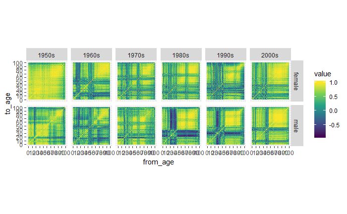

```r
dta_trnd <- dta_Mx %>%
  filter(sex != "total") %>%
  filter(code %in% c("GBRTENW")) %>%
  filter(between(year, 1950, 2010))  %>%
  filter(age <= 109) %>%
  mutate(
    decade = cut(year, breaks = seq(1950, 2010, by = 10), labels = c("1950s", "1960s", "1970s", "1980s", "1990s", "2000s"), include.lowest = TRUE)
  ) %>%
  group_by(sex, decade, year, age) %>%
  summarise(mean_Mx = mean(Mx, na.rm = T)) %>%
  ungroup() %>%
  mutate(log_mean_Mx = log(mean_Mx, 10)) %>% # Correction for Sweden
  group_by(sex, decade) %>%
  nest()
cors_df <- dta_trnd %>%
  mutate(cors = map(
    data,
    function(X) {
      X %>%
        select(-mean_Mx) %>%
        spread(age, log_mean_Mx) %>%
        select(-year) %>%
        cor()
      }
    )
  ) %>%
  mutate(cor_df = map(
    cors,
    function(X){
      X %>%
        as_tibble() %>%
        mutate(from_age = rownames(X)) %>%
        gather(key = "to_age", value = "value", -from_age) %>%
        mutate(from_age = as.numeric(from_age), to_age = as.numeric(to_age))
      }
    )
  ) %>%
  select(sex, decade, cor_df) %>%
  unnest()
cors_df %>%
  filter(from_age <= 100, to_age <= 100) %>%
  ggplot(aes(x = from_age, y = to_age, fill = value)) +
  geom_tile() +
  scale_fill_viridis_c() +
  scale_x_continuous(breaks = seq(0, 100, by = 10)) +
  scale_y_continuous(breaks = seq(0, 100, by = 10)) +
  coord_equal() +
  facet_grid(sex ~ decade)
```

Now for Scotland.

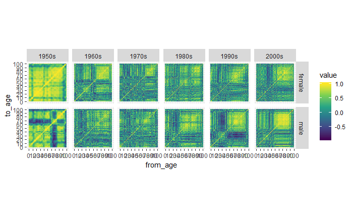

```r
dta_trnd <- dta_Mx %>%
  filter(sex != "total") %>%
  filter(code %in% c("GBR_SCO")) %>%
  filter(between(year, 1950, 2010))  %>%
  filter(age <= 109) %>%
  mutate(
    decade = cut(year, breaks = seq(1950, 2010, by = 10), labels = c("1950s", "1960s", "1970s", "1980s", "1990s", "2000s"), include.lowest = TRUE)
  ) %>%
  group_by(sex, decade, year, age) %>%
  summarise(mean_Mx = mean(Mx, na.rm = T)) %>%
  ungroup() %>%
  mutate(log_mean_Mx = log(mean_Mx + 0.00001, 10)) %>% # Correction for Sweden
  group_by(sex, decade) %>%
  nest()
cors_df <- dta_trnd %>%
  mutate(cors = map(
    data,
    function(X) {
      X %>%
        select(-mean_Mx) %>%
        spread(age, log_mean_Mx) %>%
        select(-year) %>%
        cor()
      }
    )
  ) %>%
  mutate(cor_df = map(
    cors,
    function(X){
      X %>%
        as_tibble() %>%
        mutate(from_age = rownames(X)) %>%
        gather(key = "to_age", value = "value", -from_age) %>%
        mutate(from_age = as.numeric(from_age), to_age = as.numeric(to_age))
      }
    )
  ) %>%
  select(sex, decade, cor_df) %>%
  unnest()
cors_df %>%
  filter(from_age <= 100, to_age <= 100) %>%
  ggplot(aes(x = from_age, y = to_age, fill = value)) +
  geom_tile() +
  scale_fill_viridis_c() +
  scale_x_continuous(breaks = seq(0, 100, by = 10)) +
  scale_y_continuous(breaks = seq(0, 100, by = 10)) +
  coord_equal() +
  facet_grid(sex ~ decade)
```

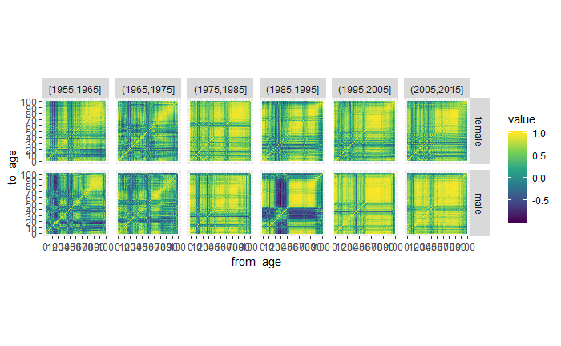

```r
dta_trnd <- dta_Mx %>%
  filter(sex != "total") %>%
  filter(code %in% c("GBRTENW")) %>%
  filter(between(year, 1955, 2015))  %>%
  filter(age <= 109) %>%
  mutate(
    decade = cut(year, breaks = seq(1955, 2015, by = 10), include.lowest = TRUE)
  ) %>%
  group_by(sex, decade, year, age) %>%
  summarise(mean_Mx = mean(Mx, na.rm = T)) %>%
  ungroup() %>%
  mutate(log_mean_Mx = log(mean_Mx, 10)) %>% # Correction for Sweden
  group_by(sex, decade) %>%
  nest()
cors_df <- dta_trnd %>%
  mutate(cors = map(
    data,
    function(X) {
      X %>%
        select(-mean_Mx) %>%
        spread(age, log_mean_Mx) %>%
        select(-year) %>%
        cor()
      }
    )
  ) %>%
  mutate(cor_df = map(
    cors,
    function(X){
      X %>%
        as_tibble() %>%
        mutate(from_age = rownames(X)) %>%
        gather(key = "to_age", value = "value", -from_age) %>%
        mutate(from_age = as.numeric(from_age), to_age = as.numeric(to_age))
      }
    )
  ) %>%
  select(sex, decade, cor_df) %>%
  unnest()
cors_df %>%
  filter(from_age <= 100, to_age <= 100) %>%
  ggplot(aes(x = from_age, y = to_age, fill = value)) +
  geom_tile() +
  scale_fill_viridis_c() +
  scale_x_continuous(breaks = seq(0, 100, by = 10)) +
  scale_y_continuous(breaks = seq(0, 100, by = 10)) +
  coord_equal() +
  facet_grid(sex ~ decade)
```

Now for Scotland.

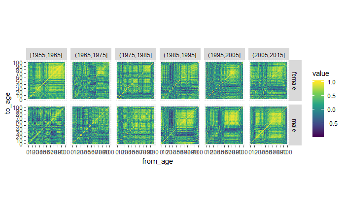

```r
dta_trnd <- dta_Mx %>%
  filter(sex != "total") %>%
  filter(code %in% c("GBR_SCO")) %>%
  filter(between(year, 1955, 2015))  %>%
  filter(age <= 109) %>%
  mutate(
    decade = cut(year, breaks = seq(1955, 2015, by = 10), include.lowest = TRUE)
  ) %>%
  group_by(sex, decade, year, age) %>%
  summarise(mean_Mx = mean(Mx, na.rm = T)) %>%
  ungroup() %>%
  mutate(log_mean_Mx = log(mean_Mx + 0.00001, 10)) %>% # Correction for Sweden
  group_by(sex, decade) %>%
  nest()
cors_df <- dta_trnd %>%
  mutate(cors = map(
    data,
    function(X) {
      X %>%
        select(-mean_Mx) %>%
        spread(age, log_mean_Mx) %>%
        select(-year) %>%
        cor()
      }
    )
  ) %>%
  mutate(cor_df = map(
    cors,
    function(X){
      X %>%
        as_tibble() %>%
        mutate(from_age = rownames(X)) %>%
        gather(key = "to_age", value = "value", -from_age) %>%
        mutate(from_age = as.numeric(from_age), to_age = as.numeric(to_age))
      }
    )
  ) %>%
  select(sex, decade, cor_df) %>%
  unnest()
cors_df %>%
  filter(from_age <= 100, to_age <= 100) %>%
  ggplot(aes(x = from_age, y = to_age, fill = value)) +
  geom_tile() +
  scale_fill_viridis_c() +
  scale_x_continuous(breaks = seq(0, 100, by = 10)) +
  scale_y_continuous(breaks = seq(0, 100, by = 10)) +
  coord_equal() +
  facet_grid(sex ~ decade)
```